# **Linking Constituency Characteristics and Social Media Engagement**

Created by Emma Jones and Maggie Parsons

*Website Link:* https://teragram04.github.io/

# Background

### The Rise of Twitter in Congressional Communication

- In **2006**, the microblogging platform then known as **twttr** debuted in the App Store.
- By **2009**, researchers at the University of Maryland identified **69 members of Congress** actively using the platform.
- According to **Golbeck et al. (2010)**, Twitter was initially used mostly for **information sharing**, not meaningful political signaling.

> With no established norms for engagement, congressional use of Twitter in its early phase was often **impersonal**, **restrained**, and **non-partisan**.

However, by **2016**, the landscape had shifted dramatically:

- Twitter and other platforms were **actively shaping political communication strategies** (Kreiss & McGregor, 2018).
- With **71% of American adults getting their news from social media** (Pew Research, 2023), digital platforms had become central to **senators’ homestyle strategies**.

### Revisiting Grimmer's Theory: Electoral Incentives and District Alignment

Grimmer classifies congressional districts into two categories:

- **Marginal Districts**: Partisan balance is relatively even.
- **Aligned Districts**: One party significantly dominates the electorate.

#### Grimmer’s Core Hypotheses:

- **Marginal senators** avoid ideological positions to prevent alienating opposition voters.  
  → Instead, they emphasize **appropriations** and **non-controversial messaging**.
- **Aligned senators**, secure in their party’s dominance, are incentivized to:
  - Defend party platforms strongly.
  - Take clear ideological positions.
  - Adopt **less moderate** stances overall.

> As a result, Grimmer concludes that **congressional discourse appears more polarized** than it actually is—driven not by ideology, but by strategic communication incentives.

### Our Central Research Question

We ask:

> **Do Grimmer’s findings on press releases still hold in the age of social media—especially on Twitter?**

Given the informal, high-frequency nature of digital platforms, we explore whether Twitter has **amplified**, **muted**, or **reshaped** the electoral incentives described by Grimmer.

# Design

## Key Questions

To answer whether Grimmer's findings hold equally among twitter posts. We also wanted to examine the possibility that other characteristics (income, diversity) may be predictors of a Senator's homestyle. The following questions, in aggregate help us assess whether this is true.

**Neccessary Questions**

1. Is frequency of bias significantly correlated with party margin in posts?
2. Is message content significantly correlated with party margin in posts?
3. Is frequency of bias in posts significantly correlated with income?
4. Is message content in posts significantly correlated with income?
5. Is frequency of bias in posts significantly correlated diversity?
6. Is message content in posts significantly correlated diversity?

## The Datasets

1. "[Political Social Media Posts](https://www.kaggle.com/datasets/crowdflower/political-social-media-posts)", pulled from Kaggle. This dataset provides a sample of 5,000 social media posts from various politicians, and categorizes them based on a myriad of variables such as bias, intended audience, a unique id for the politician, and more. This dataset will allow us to determine which kind of message politicians use the most to garner support online- e.g., do politicans favor a national audience, or one primarily composed of their constituency?
2. 2015 Census Data, Kaggle. Includes population of each group (Black, White, Hispanic, Native American, Asian, Other), as well as income per capita figures organized by county
3. Historical & Current Legislators, list the party affiliations of all legislators from https://unitedstates.github.io/congress-legislators/
4. County Census and Election Results, we created using data from https://www.presidency.ucsb.edu/statistics/elections/2012 and https://www.presidency.ucsb.edu/statistics/elections/2016
5. A few other csv's can be found in our repository, which helped us fill in the party affiliations of senators who may have had multiple names (ex. Joe/ Joseph). We gathered these using data scraping and Wikipedia and turned them into a csv to save time and memory in this notebook.

## Reference: Precise Message Type Definitions

- attack: the message attacks another politician.
- constituency: the message discusses the politician's constituency.
- information: an informational message about news in government or the wider U.S.
- media: a message about interaction with the media.
- mobilization: a message intended to mobilize supporters.
- other: a catch-all category for messages that don't fit into the others.
- personal: a personal message, usually expressing sympathy, support or condolences, or other personal opinions.
- policy: information about political policy.
- support: a message of political support.

## Hypothesis

We predict that if Grimmer’s findings hold, we would find a strong positive correlation between mobilization, policy, personal messages and aligned districts. We further hypothesize a strong positive correlation between constituency, policy messages and marginal districts. We hypothesize, in line with Grimmers assertions, neither diversity nor income will be significant predictors of homestyle.

## Variables

- Independent: Senator margins, Diversity, Income
- Dependent: Message bias, Message frequency

# Part 1: Loading and Cleaning the Data

## Loading the Data

Before examining the data, let us import the necessary libraries and clone our github website to this notebook (this is where we decided to store our dataset).

```python
import pandas as pd
import numpy as np
import matplotlib.pyplot as plt
!git clone https://github.com/Teragram04/Teragram04.github.io
%cd Teragram04.github.io
```

```
Cloning into 'Teragram04.github.io'...
remote: Enumerating objects: 55, done.
remote: Counting objects: 100% (55/55), done.
remote: Compressing objects: 100% (51/51), done.
remote: Total 55 (delta 20), reused 0 (delta 0), pack-reused 0 (from 0)
Receiving objects: 100% (55/55), 2.71 MiB | 3.34 MiB/s, done.
Resolving deltas: 100% (20/20), done.
/content/Teragram04.github.io
```

Now, we'll load in the dataset. Let's examine it before making any changes.

```python
# Original Dataset
kgposts = pd.read_csv('political_social_media.csv', encoding='iso-8859-1')
kgposts.head()
```

|  | _unit_id | _golden | _unit_state | _trusted_judgments | _last_judgment_at | audience | audience:confidence | bias | bias:confidence | message | ... | orig__golden | audience_gold | bias_gold | bioid | embed | id | label | message_gold | source | text |
| --- | --- | --- | --- | --- | --- | --- | --- | --- | --- | --- | --- | --- | --- | --- | --- | --- | --- | --- | --- | --- | --- |
| 0 | 766192484 | False | finalized | 1 | 8/4/15 21:17 | national | 1.0 | partisan | 1.0 | policy | ... | NaN | NaN | NaN | R000596 | <blockquote class="twitter-tweet" width="450">... | 3.83249E+17 | From: Trey Radel (Representative from Florida) | NaN | twitter | RT @nowthisnews: Rep. Trey Radel (R- #FL) slam... |
| 1 | 766192485 | False | finalized | 1 | 8/4/15 21:20 | national | 1.0 | partisan | 1.0 | attack | ... | NaN | NaN | NaN | M000355 | <blockquote class="twitter-tweet" width="450">... | 3.11208E+17 | From: Mitch McConnell (Senator from Kentucky) | NaN | twitter | VIDEO - #Obamacare: Full of Higher Costs and ... |
| 2 | 766192486 | False | finalized | 1 | 8/4/15 21:14 | national | 1.0 | neutral | 1.0 | support | ... | NaN | NaN | NaN | S001180 | <blockquote class="twitter-tweet" width="450">... | 3.39069E+17 | From: Kurt Schrader (Representative from Oregon) | NaN | twitter | Please join me today in remembering our fallen... |
| 3 | 766192487 | False | finalized | 1 | 8/4/15 21:08 | national | 1.0 | neutral | 1.0 | policy | ... | NaN | NaN | NaN | C000880 | <blockquote class="twitter-tweet" width="450">... | 2.98528E+17 | From: Michael Crapo (Senator from Idaho) | NaN | twitter | RT @SenatorLeahy: 1st step toward Senate debat... |
| 4 | 766192488 | False | finalized | 1 | 8/4/15 21:26 | national | 1.0 | partisan | 1.0 | policy | ... | NaN | NaN | NaN | U000038 | <blockquote class="twitter-tweet" width="450">... | 4.07643E+17 | From: Mark Udall (Senator from Colorado) | NaN | twitter | .@amazon delivery #drones show need to update ... |

5 rows × 21 columns

It looks like the chart loaded in correctly! However, there are columns here that we do not need. According to Kaggle's summary of the data, some of these variables were only utilized during the initial data collection, and provide no additional information. Let's clean up this table by removing the unnecessary columns.

```python
#The following columns were used in data collection, and will not be
#relevant for analysis. this will delete uneccesary columns
kgposts = kgposts.drop(['message_gold','orig__golden','audience_gold',
                        'bias_gold','_unit_state', '_golden'], axis=1)


kgposts.head()
```

|  | _unit_id | _trusted_judgments | _last_judgment_at | audience | audience:confidence | bias | bias:confidence | message | message:confidence | bioid | embed | id | label | source | text |
| --- | --- | --- | --- | --- | --- | --- | --- | --- | --- | --- | --- | --- | --- | --- | --- |
| 0 | 766192484 | 1 | 8/4/15 21:17 | national | 1.0 | partisan | 1.0 | policy | 1.0 | R000596 | <blockquote class="twitter-tweet" width="450">... | 3.83249E+17 | From: Trey Radel (Representative from Florida) | twitter | RT @nowthisnews: Rep. Trey Radel (R- #FL) slam... |
| 1 | 766192485 | 1 | 8/4/15 21:20 | national | 1.0 | partisan | 1.0 | attack | 1.0 | M000355 | <blockquote class="twitter-tweet" width="450">... | 3.11208E+17 | From: Mitch McConnell (Senator from Kentucky) | twitter | VIDEO - #Obamacare: Full of Higher Costs and ... |
| 2 | 766192486 | 1 | 8/4/15 21:14 | national | 1.0 | neutral | 1.0 | support | 1.0 | S001180 | <blockquote class="twitter-tweet" width="450">... | 3.39069E+17 | From: Kurt Schrader (Representative from Oregon) | twitter | Please join me today in remembering our fallen... |
| 3 | 766192487 | 1 | 8/4/15 21:08 | national | 1.0 | neutral | 1.0 | policy | 1.0 | C000880 | <blockquote class="twitter-tweet" width="450">... | 2.98528E+17 | From: Michael Crapo (Senator from Idaho) | twitter | RT @SenatorLeahy: 1st step toward Senate debat... |
| 4 | 766192488 | 1 | 8/4/15 21:26 | national | 1.0 | partisan | 1.0 | policy | 1.0 | U000038 | <blockquote class="twitter-tweet" width="450">... | 4.07643E+17 | From: Mark Udall (Senator from Colorado) | twitter | .@amazon delivery #drones show need to update ... |

Now that we have removed unnecessary columns, let us check to make sure all the remaining columns are the correct dtype.

We'd further like to analyze certain characteristics by party membership and state. So we'll need to isolate these characteristics from the label column.

```python
kgposts['legislator_Name'] = kgposts['label'].str.extract(r'From: (.*?) \(')
kgposts['state'] =kgposts['label'].str.extract(r'from ([A-Za-z\s]+)\)')
kgposts.head()
```

|  | _unit_id | _trusted_judgments | _last_judgment_at | audience | audience:confidence | bias | bias:confidence | message | message:confidence | bioid | embed | id | label | source | text | legislator_Name | state |
| --- | --- | --- | --- | --- | --- | --- | --- | --- | --- | --- | --- | --- | --- | --- | --- | --- | --- |
| 0 | 766192484 | 1 | 8/4/15 21:17 | national | 1.0 | partisan | 1.0 | policy | 1.0 | R000596 | <blockquote class="twitter-tweet" width="450">... | 3.83249E+17 | From: Trey Radel (Representative from Florida) | twitter | RT @nowthisnews: Rep. Trey Radel (R- #FL) slam... | Trey Radel | Florida |
| 1 | 766192485 | 1 | 8/4/15 21:20 | national | 1.0 | partisan | 1.0 | attack | 1.0 | M000355 | <blockquote class="twitter-tweet" width="450">... | 3.11208E+17 | From: Mitch McConnell (Senator from Kentucky) | twitter | VIDEO - #Obamacare: Full of Higher Costs and ... | Mitch McConnell | Kentucky |
| 2 | 766192486 | 1 | 8/4/15 21:14 | national | 1.0 | neutral | 1.0 | support | 1.0 | S001180 | <blockquote class="twitter-tweet" width="450">... | 3.39069E+17 | From: Kurt Schrader (Representative from Oregon) | twitter | Please join me today in remembering our fallen... | Kurt Schrader | Oregon |
| 3 | 766192487 | 1 | 8/4/15 21:08 | national | 1.0 | neutral | 1.0 | policy | 1.0 | C000880 | <blockquote class="twitter-tweet" width="450">... | 2.98528E+17 | From: Michael Crapo (Senator from Idaho) | twitter | RT @SenatorLeahy: 1st step toward Senate debat... | Michael Crapo | Idaho |
| 4 | 766192488 | 1 | 8/4/15 21:26 | national | 1.0 | partisan | 1.0 | policy | 1.0 | U000038 | <blockquote class="twitter-tweet" width="450">... | 4.07643E+17 | From: Mark Udall (Senator from Colorado) | twitter | .@amazon delivery #drones show need to update ... | Mark Udall | Colorado |

Now, we'll add in a dataset which matches senator names with party. This dataset was compiled by https://unitedstates.github.io/congress-legislators/ using Goverment websites.

```python
# adds current legislators
partydf = pd.read_csv('legislators-current.csv')
selected_columns = ['full_name', 'party']
partydf = partydf[selected_columns]
partydf = partydf.rename(columns={'full_name': 'legislator_Name'})
kgposts = pd.merge(kgposts, partydf, on='legislator_Name', how='left')
```

```python
# adds historical legislators
partydf = pd.read_csv('legislators-historical.csv')
selected_columns = ['full_name', 'party']
partydf = partydf[selected_columns]
partydf = partydf.rename(columns={'full_name': 'legislator_Name', 'party': 'party_hist'}) # Rename 'party' to 'party_hist'
kgposts = pd.merge(kgposts, partydf, on='legislator_Name', how='left')

# Update the 'party' column in kgposts with values from 'party_hist'
kgposts['party'] = kgposts['party'].fillna(kgposts['party_hist'])

# Drop the 'party_hist' column
kgposts = kgposts.drop(columns=['party_hist'])
kgposts.head()
```

|  | _unit_id | _trusted_judgments | _last_judgment_at | audience | audience:confidence | bias | bias:confidence | message | message:confidence | bioid | embed | id | label | source | text | legislator_Name | state | party |
| --- | --- | --- | --- | --- | --- | --- | --- | --- | --- | --- | --- | --- | --- | --- | --- | --- | --- | --- |
| 0 | 766192484 | 1 | 8/4/15 21:17 | national | 1.0 | partisan | 1.0 | policy | 1.0 | R000596 | <blockquote class="twitter-tweet" width="450">... | 3.83249E+17 | From: Trey Radel (Representative from Florida) | twitter | RT @nowthisnews: Rep. Trey Radel (R- #FL) slam... | Trey Radel | Florida | Republican |
| 1 | 766192485 | 1 | 8/4/15 21:20 | national | 1.0 | partisan | 1.0 | attack | 1.0 | M000355 | <blockquote class="twitter-tweet" width="450">... | 3.11208E+17 | From: Mitch McConnell (Senator from Kentucky) | twitter | VIDEO - #Obamacare: Full of Higher Costs and ... | Mitch McConnell | Kentucky | Republican |
| 2 | 766192486 | 1 | 8/4/15 21:14 | national | 1.0 | neutral | 1.0 | support | 1.0 | S001180 | <blockquote class="twitter-tweet" width="450">... | 3.39069E+17 | From: Kurt Schrader (Representative from Oregon) | twitter | Please join me today in remembering our fallen... | Kurt Schrader | Oregon | Democrat |
| 3 | 766192487 | 1 | 8/4/15 21:08 | national | 1.0 | neutral | 1.0 | policy | 1.0 | C000880 | <blockquote class="twitter-tweet" width="450">... | 2.98528E+17 | From: Michael Crapo (Senator from Idaho) | twitter | RT @SenatorLeahy: 1st step toward Senate debat... | Michael Crapo | Idaho | NaN |
| 4 | 766192488 | 1 | 8/4/15 21:26 | national | 1.0 | partisan | 1.0 | policy | 1.0 | U000038 | <blockquote class="twitter-tweet" width="450">... | 4.07643E+17 | From: Mark Udall (Senator from Colorado) | twitter | .@amazon delivery #drones show need to update ... | Mark Udall | Colorado | Democrat |

Some legislators' parties are still missing from the data set

```python
#get a list of all senators whose party is listed as Nan
missing_parties = kgposts[kgposts['party'].isna()]['legislator_Name'].unique()
```

This revealed that 7 legislators' names where not written correctly, likely due to a unicode error. We fix that here.

```python
kgposts['legislator_Name'] = kgposts['legislator_Name'].str.replace('AndrÌ© Carson', 'André Carson')
kgposts['legislator_Name'] = kgposts['legislator_Name'].str.replace('RaÌ¼l Grijalva', 'Raúl Grijalva')
kgposts['legislator_Name'] = kgposts['legislator_Name'].str.replace('JosÌ© Serrano', 'José Serrano')
kgposts['legislator_Name'] = kgposts['legislator_Name'].str.replace('RubÌ©n Hinojosa', 'Rubén Hinojosa')
kgposts['legislator_Name'] = kgposts['legislator_Name'].str.replace('Beto O&#x27;Rourke', 'Beto O\'Rourke')
kgposts['legislator_Name'] = kgposts['legislator_Name'].str.replace('Gregorio &#x27;Kilili&#x27; Sablan', 'Gregorio \'Kilili\' Sablan')
kgposts['legislator_Name'] = kgposts['legislator_Name'].str.replace('Nydia VelÌÁzquez', 'Nydia Velázquez')
```

```python
kgposts.head(100)
```

|  | _unit_id | _trusted_judgments | _last_judgment_at | audience | audience:confidence | bias | bias:confidence | message | message:confidence | bioid | embed | id | label | source | text | legislator_Name | state | party |
| --- | --- | --- | --- | --- | --- | --- | --- | --- | --- | --- | --- | --- | --- | --- | --- | --- | --- | --- |
| 0 | 766192484 | 1 | 8/4/15 21:17 | national | 1.0 | partisan | 1.0000 | policy | 1.0 | R000596 | <blockquote class="twitter-tweet" width="450">... | 3.83249E+17 | From: Trey Radel (Representative from Florida) | twitter | RT @nowthisnews: Rep. Trey Radel (R- #FL) slam... | Trey Radel | Florida | Republican |
| 1 | 766192485 | 1 | 8/4/15 21:20 | national | 1.0 | partisan | 1.0000 | attack | 1.0 | M000355 | <blockquote class="twitter-tweet" width="450">... | 3.11208E+17 | From: Mitch McConnell (Senator from Kentucky) | twitter | VIDEO - #Obamacare: Full of Higher Costs and ... | Mitch McConnell | Kentucky | Republican |
| 2 | 766192486 | 1 | 8/4/15 21:14 | national | 1.0 | neutral | 1.0000 | support | 1.0 | S001180 | <blockquote class="twitter-tweet" width="450">... | 3.39069E+17 | From: Kurt Schrader (Representative from Oregon) | twitter | Please join me today in remembering our fallen... | Kurt Schrader | Oregon | Democrat |
| 3 | 766192487 | 1 | 8/4/15 21:08 | national | 1.0 | neutral | 1.0000 | policy | 1.0 | C000880 | <blockquote class="twitter-tweet" width="450">... | 2.98528E+17 | From: Michael Crapo (Senator from Idaho) | twitter | RT @SenatorLeahy: 1st step toward Senate debat... | Michael Crapo | Idaho | NaN |
| 4 | 766192488 | 1 | 8/4/15 21:26 | national | 1.0 | partisan | 1.0000 | policy | 1.0 | U000038 | <blockquote class="twitter-tweet" width="450">... | 4.07643E+17 | From: Mark Udall (Senator from Colorado) | twitter | .@amazon delivery #drones show need to update ... | Mark Udall | Colorado | Democrat |
| ... | ... | ... | ... | ... | ... | ... | ... | ... | ... | ... | ... | ... | ... | ... | ... | ... | ... | ... |
| 95 | 766192579 | 1 | 8/4/15 20:14 | national | 1.0 | neutral | 1.0000 | personal | 1.0 | M000702 | <blockquote class="twitter-tweet" width="450">... | 4.09056E+17 | From: Barbara Mikulski (Senator from Maryland) | twitter | Mandela. Chg. South Africa chg the world. Insp... | Barbara Mikulski | Maryland | NaN |
| 96 | 766192580 | 1 | 8/4/15 21:03 | national | 1.0 | neutral | 1.0000 | personal | 1.0 | H001047 | <blockquote class="twitter-tweet" width="450">... | 2.88011E+17 | From: Jim Himes (Representative from Connecticut) | twitter | Got a mess of oysters and clams out on Sound t... | Jim Himes | Connecticut | NaN |
| 97 | 766192581 | 2 | 8/4/15 21:41 | national | 1.0 | neutral | 0.5294 | mobilization | 1.0 | F000462 | <blockquote class="twitter-tweet" width="450">... | 3.57985E+17 | From: Lois Frankel (Representative from Florida) | twitter | RT if you think America succeeds when #WomenSu... | Lois Frankel | Florida | Democrat |
| 98 | 766192582 | 1 | 8/4/15 20:14 | national | 1.0 | neutral | 1.0000 | information | 1.0 | K000378 | <blockquote class="twitter-tweet" width="450">... | 4.05489E+17 | From: Adam Kinzinger (Representative from Illi... | twitter | Tips for staying warm should you be outside th... | Adam Kinzinger | Illinois | Republican |
| 99 | 766192583 | 1 | 8/4/15 20:23 | constituency | 1.0 | neutral | 1.0000 | media | 1.0 | S001183 | <blockquote class="twitter-tweet" width="450">... | 3.49163E+17 | From: David Schweikert (Representative from Ar... | twitter | RT @kevinscholla: My interview w/@RepDavid Sch... | David Schweikert | Arizona | Republican |

100 rows × 18 columns

```python
kgposts.dtypes
```

|  | 0 |
| --- | --- |
| _unit_id | int64 |
| _trusted_judgments | int64 |
| _last_judgment_at | object |
| audience | object |
| audience:confidence | float64 |
| bias | object |
| bias:confidence | float64 |
| message | object |
| message:confidence | float64 |
| bioid | object |
| embed | object |
| id | object |
| label | object |
| source | object |
| text | object |
| legislator_Name | object |
| state | object |
| party | object |

**dtype:** object

Stepping through these labels, a few stand out. Because _unit_id is a unique identifier for each post, we don't necesarily need it to be an integer (they aren't storing quantitative data and could just as easily store a unique string of letters). Let's cast this to an object.

```python
kgposts._unit_id = kgposts._unit_id.astype(str)
kgposts._unit_id
```

|  | _unit_id |
| --- | --- |
| 0 | 766192484 |
| 1 | 766192485 |
| 2 | 766192486 |
| 3 | 766192487 |
| 4 | 766192488 |
| ... | ... |
| 4995 | 766197482 |
| 4996 | 766197483 |
| 4997 | 766197484 |
| 4998 | 766197485 |
| 4999 | 766197486 |

5000 rows × 1 columns

**dtype:** object

Meanwhile, _trusted_judgements can remain an integer, as we could perform quantitative operations to determine outcomes (e.g, what is the average number of _trusted_judgrments per post?) The rest of the variables appear to be the correct type.

```python
#find the values for kg posts which are still NaN and associated legislator names
missing_parties = kgposts[kgposts['party'].isna()]['legislator_Name'].unique()
```

## Cleaning, Legislators and Party Affliation

This turned out to be quite a lengthy process, so we did it in a seperate notebook and turned it into a csv which was then uploaded to the github.

```python
'''partydf2 = pd.read_csv('fixedfinalmissingleg.csv')

partydf2 = partydf2.rename(columns={'Name': 'legislator_Name'})
kgposts = pd.merge(kgposts, partydf, on='legislator_Name', how='left')'''

# Load partydf2
partydf2 = pd.read_csv('fixedfinalmissingleg.csv')
partydf2 = partydf2.rename(columns={'Name': 'legislator_Name'})

# Clean legislator names in both DataFrames
kgposts['legislator_Name'] = kgposts['legislator_Name'].str.strip()  # Remove leading/trailing spaces
partydf2['legislator_Name'] = partydf2['legislator_Name'].str.strip()

# Merge on cleaned names using 'left' join to keep all kgposts rows
kgposts = pd.merge(kgposts, partydf2[['legislator_Name', 'Party']], on='legislator_Name', how='left')

# Update 'party' column with values from 'Party'
kgposts['party'] = kgposts['party'].fillna(kgposts['Party'])

# Drop the temporary 'Party' column
kgposts = kgposts.drop(columns=['Party'])

kgposts.head()
```

|  | _unit_id | _trusted_judgments | _last_judgment_at | audience | audience:confidence | bias | bias:confidence | message | message:confidence | bioid | embed | id | label | source | text | legislator_Name | state | party |
| --- | --- | --- | --- | --- | --- | --- | --- | --- | --- | --- | --- | --- | --- | --- | --- | --- | --- | --- |
| 0 | 766192484 | 1 | 8/4/15 21:17 | national | 1.0 | partisan | 1.0 | policy | 1.0 | R000596 | <blockquote class="twitter-tweet" width="450">... | 3.83249E+17 | From: Trey Radel (Representative from Florida) | twitter | RT @nowthisnews: Rep. Trey Radel (R- #FL) slam... | Trey Radel | Florida | Republican |
| 1 | 766192485 | 1 | 8/4/15 21:20 | national | 1.0 | partisan | 1.0 | attack | 1.0 | M000355 | <blockquote class="twitter-tweet" width="450">... | 3.11208E+17 | From: Mitch McConnell (Senator from Kentucky) | twitter | VIDEO - #Obamacare: Full of Higher Costs and ... | Mitch McConnell | Kentucky | Republican |
| 2 | 766192486 | 1 | 8/4/15 21:14 | national | 1.0 | neutral | 1.0 | support | 1.0 | S001180 | <blockquote class="twitter-tweet" width="450">... | 3.39069E+17 | From: Kurt Schrader (Representative from Oregon) | twitter | Please join me today in remembering our fallen... | Kurt Schrader | Oregon | Democrat |
| 3 | 766192487 | 1 | 8/4/15 21:08 | national | 1.0 | neutral | 1.0 | policy | 1.0 | C000880 | <blockquote class="twitter-tweet" width="450">... | 2.98528E+17 | From: Michael Crapo (Senator from Idaho) | twitter | RT @SenatorLeahy: 1st step toward Senate debat... | Michael Crapo | Idaho | Democratic |
| 4 | 766192488 | 1 | 8/4/15 21:26 | national | 1.0 | partisan | 1.0 | policy | 1.0 | U000038 | <blockquote class="twitter-tweet" width="450">... | 4.07643E+17 | From: Mark Udall (Senator from Colorado) | twitter | .@amazon delivery #drones show need to update ... | Mark Udall | Colorado | Democrat |

```python
senators2015 = ['Patrick Leahy', 'Orrin Hatch', 'Thad Cochran', 'Chuck Grassley', 'Mitch McConnell', 'Barbara Mikulski', 'Richard Shelby', 'John McCain', 'Harry Reid', 'Dianne Feinstein', 'Barbara Boxer', 'Patty Murray', 'Jim Inhofe', 'Ron Wyden', 'Pat Roberts', 'Dick Durbin', 'Jack Reed', 'Jeff Sessions', 'Susan Collins', 'Mike Enzi', 'Chuck Schumer', 'Michael Crapo', 'Bill Nelson', 'Tom Carper', 'Debbie Stabenow', 'Maria Cantwell', 'John Cornyn', 'Lisa Murkowski', 'Lindsey Graham', 'Lamar Alexander', 'Richard Burr', 'John Thune', 'Johnny Isakson', 'David Vitter', 'Bob Menendez', 'Ben Cardin', 'Bernie Sanders', 'Sherrod Brown', 'Bob Casey Jr', 'Bob Corker', 'Claire McCaskill', 'Amy Klobuchar', 'Sheldon Whitehouse', 'Jon Tester', 'John Barrasso', 'Roger Wicker', 'Tom Udall', 'Jeanne Shaheen', 'Mark Warner', 'Jim Risch', 'Jeff Merkley', 'Michael Bennet', 'Kirsten Gillibrand', 'Al Franken', 'Joe Manchin', 'Chris Coons', 'Mark Kirk', 'Dan Coats', 'Roy Blunt', 'Jerry Moran', 'Rob Portman', 'John Boozman', 'Pat Toomey', 'John Hoeven', 'Marco Rubio', 'Ron Johnson', 'Rand Paul', 'Richard Blumenthal', 'Mike Lee', 'Kelly Ayotte', 'Dean Heller', 'Brian Schatz', 'Tim Scott', 'Tammy Baldwin', 'Jeff Flake', 'Joe Donnelly', 'Chris Murphy', 'Mazie Hirono','Martin Heinrich', 'Angus King', 'Tim Kaine', 'Ted Cruz', 'Elizabeth Warren', 'Deb Fischer', 'Heidi Heitkamp', 'Ed Markey', 'Cory Booker', 'Shelley Moore Capito', 'Gary Peters', 'Bill Cassidy', 'Cory Gardner', 'James Lankford', 'Tom Cotton', 'Steve Daines', 'Mike Rounds', 'David Perdue', 'Thom Tillis', 'Joni Ernst', 'Ben Sasse', 'Dan Sullivan']
#get all kaggleposts where legislator name matches one in senators2015
senators2015_posts = kgposts[kgposts['legislator_Name'].isin(senators2015)]

senators2015_posts.head()
#for all values of party which = Democrat, change to Democratic
senators2015_posts.loc[senators2015_posts['party'] == 'Democrat', 'party'] = 'Democratic'
```

Moving beyond just social media messages, what if we want to learn more about the populations the politicians are targeting? To begin, let's read in some census data from 2015.

## Load Census Data

```python
census_data_2015 = pd.read_csv('acs2015_county_data.csv')

census_data_2015.head()
```

|  | CensusId | State | County | TotalPop | Men | Women | Hispanic | White | Black | Native | ... | Walk | OtherTransp | WorkAtHome | MeanCommute | Employed | PrivateWork | PublicWork | SelfEmployed | FamilyWork | Unemployment |
| --- | --- | --- | --- | --- | --- | --- | --- | --- | --- | --- | --- | --- | --- | --- | --- | --- | --- | --- | --- | --- | --- |
| 0 | 1001 | Alabama | Autauga | 55221 | 26745 | 28476 | 2.6 | 75.8 | 18.5 | 0.4 | ... | 0.5 | 1.3 | 1.8 | 26.5 | 23986 | 73.6 | 20.9 | 5.5 | 0.0 | 7.6 |
| 1 | 1003 | Alabama | Baldwin | 195121 | 95314 | 99807 | 4.5 | 83.1 | 9.5 | 0.6 | ... | 1.0 | 1.4 | 3.9 | 26.4 | 85953 | 81.5 | 12.3 | 5.8 | 0.4 | 7.5 |
| 2 | 1005 | Alabama | Barbour | 26932 | 14497 | 12435 | 4.6 | 46.2 | 46.7 | 0.2 | ... | 1.8 | 1.5 | 1.6 | 24.1 | 8597 | 71.8 | 20.8 | 7.3 | 0.1 | 17.6 |
| 3 | 1007 | Alabama | Bibb | 22604 | 12073 | 10531 | 2.2 | 74.5 | 21.4 | 0.4 | ... | 0.6 | 1.5 | 0.7 | 28.8 | 8294 | 76.8 | 16.1 | 6.7 | 0.4 | 8.3 |
| 4 | 1009 | Alabama | Blount | 57710 | 28512 | 29198 | 8.6 | 87.9 | 1.5 | 0.3 | ... | 0.9 | 0.4 | 2.3 | 34.9 | 22189 | 82.0 | 13.5 | 4.2 | 0.4 | 7.7 |

5 rows × 37 columns

This looks like a good overview, but there are some issues we need to address. Going forward, we want to examine this data on a statewide basis, not a county-wide one. To address this, let's create a new dataframe that will include either the summation or the average of the values we want to study to get a picture of an entire state's makeup.

```python
#Create a new dataframe that looks at the census info on a state-wide basis.
#Sum the integers and average the percentages

Census_Data_Statewide = census_data_2015.groupby('State').apply(lambda x: pd.Series({
    'TotalPop': x['TotalPop'].sum(),
    'Hispanic': (x['Hispanic'] * x['TotalPop']).sum() / x['TotalPop'].sum(),
    'White': (x['White'] * x['TotalPop']).sum() / x['TotalPop'].sum(),
    'Black': (x['Black'] * x['TotalPop']).sum() / x['TotalPop'].sum(),
    'Native': (x['Native'] * x['TotalPop']).sum() / x['TotalPop'].sum(),
    'Asian': (x['Asian'] * x['TotalPop']).sum() / x['TotalPop'].sum(),
    'Pacific': (x['Pacific'] * x['TotalPop']).sum() / x['TotalPop'].sum(),
    'Men': x['Men'].sum(),
    'Women': x['Women'].sum(),
    'PublicWork': (x['PublicWork'] * x['TotalPop']).sum() / x['TotalPop'].sum(),
    'PrivateWork': (x['PrivateWork'] * x['TotalPop']).sum() / x['TotalPop'].sum(),
    'IncomePerCap': (x['IncomePerCap'] * x['TotalPop']).sum() / x['TotalPop'].sum(),
    'Income': (x['Income'] * x['TotalPop']).sum() / x['TotalPop'].sum()
}))

Census_Data_Statewide.head()
```

| State | TotalPop | Hispanic | White | Black | Native | Asian | Pacific | Men | Women | PublicWork | PrivateWork | IncomePerCap | Income |
| --- | --- | --- | --- | --- | --- | --- | --- | --- | --- | --- | --- | --- | --- |
| Alabama | 4830620.0 | 3.999312 | 66.341142 | 26.302823 | 0.456166 | 1.228718 | 0.022674 | 2341093.0 | 2489527.0 | 16.313379 | 78.223720 | 24091.518226 | 44531.621127 |
| Alaska | 733375.0 | 6.527632 | 62.376392 | 3.221664 | 13.416348 | 5.772953 | 1.179333 | 384160.0 | 349215.0 | 25.585478 | 67.935430 | 33413.428663 | 72351.565897 |
| Arizona | 6641928.0 | 30.338523 | 56.488653 | 3.959995 | 4.002505 | 2.917963 | 0.174526 | 3299088.0 | 3342840.0 | 15.162412 | 78.766693 | 25847.425295 | 50406.923807 |
| Arkansas | 2958208.0 | 6.870799 | 73.596324 | 15.436414 | 0.560054 | 1.352033 | 0.224281 | 1451913.0 | 1506295.0 | 16.455038 | 76.992934 | 22798.448086 | 41977.085065 |
| California | 38421464.0 | 38.380974 | 38.725035 | 5.616552 | 0.376623 | 13.515132 | 0.346866 | 19087135.0 | 19334329.0 | 14.042380 | 77.524942 | 30318.055748 | 63198.081918 |

We now have a dataframe that allows us to look at the reported information based on state, and we have removed all erroneous information that we don't plan on using going forward.

Now, we have to isolate the politicians whose messages we want to study in relation to the state census data. to do this, we will isolate all the senators who served in 2015 (as senators, unlike representatives, represent the whole state).

```python
#Remove unnecessary columns
clean_senators_2015 = senators2015_posts.drop(columns = ['_unit_id','_trusted_judgments','_last_judgment_at','audience:confidence',
                                                         'bias:confidence','message:confidence','bioid','embed','id','label','text'])
clean_senators_2015.head()
```

|  | audience | bias | message | source | legislator_Name | state | party |
| --- | --- | --- | --- | --- | --- | --- | --- |
| 1 | national | partisan | attack | twitter | Mitch McConnell | Kentucky | Republican |
| 3 | national | neutral | policy | twitter | Michael Crapo | Idaho | Democratic |
| 5 | national | partisan | information | twitter | Heidi Heitkamp | North Dakota | Democratic |
| 15 | national | partisan | policy | twitter | Kirsten Gillibrand | New York | Democratic |
| 16 | national | neutral | personal | twitter | Cory Booker | New Jersey | Democratic |

## Load Voter Margins

```python
margins = pd.read_csv('PresidentMargins.csv', encoding='iso-8859-1')
margins = margins.rename(columns={'ï»¿State': 'State'})
margins.head()
```

|  | State | Dem-2016 | Rep-2016 | Margin-2016 | Dem-2012 | Rep-2012 | Margin-2012 | shift | avg |
| --- | --- | --- | --- | --- | --- | --- | --- | --- | --- |
| 0 | Alabama | 0.34 | 0.62 | 0.28 | 0.38 | 0.61 | 0.221 | -0.06 | 0.2505 |
| 1 | Alaska | 0.37 | 0.51 | 0.14 | 0.41 | 0.55 | 0.140 | 0.00 | 0.1400 |
| 2 | Arizona | 0.45 | 0.48 | 0.03 | 0.45 | 0.54 | 0.091 | 0.06 | 0.0605 |
| 3 | Arkansas | 0.34 | 0.61 | 0.27 | 0.37 | 0.61 | 0.237 | -0.03 | 0.2535 |
| 4 | California | 0.62 | 0.32 | -0.30 | 0.60 | 0.37 | -0.231 | 0.07 | -0.2655 |

Now, let's sort these messages by state and count the number of bias vs neutral messages and message types.

```python
#Count the various message types.
social_media_values = clean_senators_2015.groupby('state').agg({
    'message': 'value_counts',
    })
social_media_values.head(10)
```

| state | message | message |
| --- | --- | --- |
| Alabama | policy | 5 |
|  | media | 3 |
|  | support | 2 |
|  | mobilization | 1 |
| Alaska | personal | 7 |
|  | policy | 7 |
|  | support | 4 |
|  | information | 2 |
| Arizona | personal | 7 |
|  | media | 4 |

```python
#Count the difference in bias
social_media_bias = clean_senators_2015.groupby('state').agg({
    'bias': 'value_counts',
    })
social_media_bias.head()
```

| state | bias | bias |
| --- | --- | --- |
| Alabama | partisan | 8 |
|  | neutral | 3 |
| Alaska | neutral | 13 |
|  | partisan | 7 |
| Arizona | neutral | 19 |

Double check no senators where missed

```python
# senators2015 the list from earlier compare to senators who's name appear in the cleaned_senators_2015 df
for i in senators2015:
  if i not in clean_senators_2015['legislator_Name'].values:
    print(i)
```

```
Chuck Grassley
Jim Inhofe
Dick Durbin
Mike Enzi
Chuck Schumer
Tom Carper
Bob Menendez
Ben Cardin
Bernie Sanders
Bob Casey Jr
Jim Risch
Joe Manchin
Chris Coons
Dan Coats
Pat Toomey
Chris Murphy
Mazie Hirono
Ed Markey
Shelley Moore Capito
Mike Rounds
David Perdue
Thom Tillis
Joni Ernst
Ben Sasse
Dan Sullivan
```

The easiest way to review if these senators exist in the kaggle set under a different way is simply by checking manually

```python
print(kgposts['legislator_Name'].unique()) # Call unique() with parentheses to get the unique values before accessing .values
```

```
['Trey Radel' 'Mitch McConnell' 'Kurt Schrader' 'Michael Crapo'
 'Mark Udall' 'Heidi Heitkamp' 'Frederica Wilson' 'Ron Barber'
 'Chuck Fleischmann' 'Steny Hoyer' 'John Fleming' 'Adam Kinzinger'
 'Thomas Carper' 'Gregg Harper' 'John Dingell' 'Kirsten Gillibrand'
 'Cory Booker' 'Elizabeth Esty' 'Eric Cantor' 'Paul Tonko' 'Orrin Hatch'
 'Niki Tsongas' 'Kerry Bentivolio' 'Pete Sessions' 'John Rockefeller IV'
 'Steve Womack' 'Randy Hultgren' 'Bob Casey' 'Steve Daines' 'Tom Price'
 'Sander Levin' 'Chris Collins' 'Martha Roby' 'C.A. Dutch Ruppersberger'
 'Lindsey Graham' 'Lee Terry' 'Timothy Bishop' 'Debbie Wasserman Schultz'
 'Vern Buchanan' 'John McCain' 'Mark Pocan' 'Tom Harkin' 'Chaka Fattah'
 'Edward Markey' 'Patrick Murphy' 'Cory Gardner' 'Ileana Ros-Lehtinen'
 'Scott Peters' 'Adam Schiff' 'Doug Lamborn' 'Kyrsten Sinema'
 'Kevin McCarthy' 'Robert Scott' 'Robert Goodlatte' 'Billy Long'
 'Jack Kingston' 'Mario Diaz-Balart' 'Brian Higgins' 'Roy Blunt'
 'Bernard Sanders' 'Yvette Clarke' 'Michael McCaul' 'Daniel Lipinski'
 'Nita Lowey' 'Lynn Jenkins' 'Tom Rooney' 'Tom Graves' 'Jeanne Shaheen'
 'John Shimkus' 'John Barrasso' 'Amy Klobuchar' 'Raul Ruiz' 'Richard Burr'
 'Mike Lee' 'Bill Cassidy' 'Harold Rogers' 'Tim Walz' 'Patrick Leahy'
 'Jim Langevin' 'Michele Bachmann' 'Barbara Mikulski' 'Jim Himes'
 'Lois Frankel' 'David Schweikert' 'Vicky Hartzler' 'Scott Perry'
 'John Boehner' 'Joe Heck' 'Phil Roe' 'Peter Roskam' 'Bob Corker'
 'Erik Paulsen' 'Bill Enyart' 'Pat Roberts' 'Robert Pittenger'
 'Mark Meadows' 'Eleanor Norton' 'Joe Barton' 'John Culberson'
 'Chris Van Hollen' 'Todd Rokita' 'Dana Rohrabacher' 'Donna Edwards'
 'Maria Cantwell' 'Tammy Baldwin' 'Donald Payne Jr.' 'Pat Meehan'
 'Michael Fitzpatrick' 'Betty McCollum' 'Mike Pompeo' 'Richard Blumenthal'
 'Kelly Ayotte' 'Dan Benishek' 'Sheila Jackson-Lee' 'Bill Johnson'
 'André Carson' 'Ann Wagner' 'John Cornyn' 'John Hoeven'
 'Christopher Murphy' 'Robert Wittman' 'Sean Maloney' 'Barbara Boxer'
 'Dean Heller' 'Jerry McNerney' 'Tom Cotton' 'Mike Coffman'
 'Benjamin Cardin' 'Larry Bucshon' 'Darrell Issa' 'Rob Portman'
 'John Garamendi' 'Cedric Richmond' 'Alan Grayson' 'Patrick McHenry'
 'Sheldon Whitehouse' 'Sherrod Brown' 'Edward Whitfield' 'Janice Hahn'
 'Stephen Fincher' 'Scott DesJarlais' 'John Delaney' 'Brad Wenstrup'
 'Jack Reed' 'Blake Farenthold' 'Joyce Beatty' 'Kevin Brady' 'Todd Young'
 'Candice Miller' 'Mark Pryor' 'Glenn Thompson' 'Dina Titus' 'Tim Scott'
 'David Price' 'Jim McGovern' 'Thomas Massie' 'Frank Pallone'
 'Michael Turner' 'Scott Tipton' 'Michelle Lujan Grisham' 'Joe Donnelly'
 'Tim Huelskamp' 'Raul Labrador' 'Bill Flores' 'Charles Grassley'
 'Marco Rubio' 'David McKinley' 'Dave Joyce' 'Ken Calvert' 'Jeff Merkley'
```

[output cut: 63 more lines]

```
 'Chellie Pingree' 'Gene Green' 'Sam Johnson' 'F. Sensenbrenner'
 'Mike McIntyre' 'Rush Holt' 'Henry Waxman' 'Bobby Rush'
 'Colleen Hanabusa' 'Peter King' 'Austin Scott' 'Michael Michaud'
 'William Cowan' 'Alan Nunnelee' 'Martin Heinrich' 'Madeleine Bordallo'
 'G. Butterfield' 'Lou Barletta' 'Bradley Byrne' 'Michael Capuano'
 'Joseph Crowley' 'Katherine Clark' 'Danny Davis' 'Peter DeFazio'
 'Mike Doyle' 'Charlie Dent' 'Suzan DelBene' 'Luis Gutierrez' 'Sam Graves'
 'Al Green' 'Bob Gibbs' 'Alcee Hastings' 'Rubén Hinojosa' 'Duncan Hunter'
 'Jaime Herrera Beutler' 'James Inhofe' 'Steve King' 'Ann Kirkpatrick'
 'Bill Keating' 'Derek Kilmer' 'Leonard Lance' 'Cynthia Lummis'
 'Jim McDermott' 'John Mica' 'Doris Matsui' "Beto O'Rourke"
 'Pedro Pierluisi' 'Mark Sanford' 'Charles Schumer' 'Mike Simpson'
 'Albio Sires' "Gregorio 'Kilili' Sablan" 'Chris Stewart' 'Pat Tiberi'
 'Jon Tester' 'Nydia Velázquez' 'Filemon Vela' 'Joe Wilson' 'Rob Woodall'
 'Elizabeth Warren']
```

- Chuck Grassley = Charles Grassley
- Joe Manchin = Joe Manchin III
- Jim Inhofe = James Inhofe
- Dick Durbin = Richard Durbin
- Mike Enzi = Michael Enzi
- Chuck Schumer = Charles Schumer
- Tom Carper = Thomas Carper
- Bob Menendez = Robert Menendez
- Ben Cardin = Benjamin Cardin
- Bernie Sanders = Bernard Sanders
- Bob Casey Jr = Bob Casey
- Chris Coons = Christopher Coons
- Dan Coats = Daniel Coats
- Pat Toomey= Patrick Toomey
- Chris Murphy = Christopher Murphy
- Ed Markey = Edward Markey
- Shelley Moore Capito = Shelley Capito
- Mike Rounds - not found
- David Perdue - not found
- Thom Tillis - not found
- Joni Ernst - not found
- Ben Sasse - not found
- Dan Sullivan - not found
- Jim Risch - not found
- Mazie Hirono - not found

```python
senators2015_posts['legislator_Name'].nunique()
```

```
75
```

```python
senstoadd = ['Charles Grassley', 'Joe Manchin III', 'James Inhofe', 'Richard Durbin', 'Michael Enzi',
     'Charles Schumer',
   'Thomas Carper',
    'Robert Menendez',
    'Benjamin Cardin',
    'Bernard Sanders',
    'Bob Casey',
    'Christopher Coons',
     'Daniel Coats',
     'Patrick Toomey',
   'Christopher Murphy',
   'Edward Markey',
    'Shelley Capito' ] # 17 new names
senators2015_posts2 = kgposts[kgposts['legislator_Name'].isin(senstoadd)]
senators2015_posts = pd.concat([senators2015_posts, senators2015_posts2])
```

```python
senators2015_posts['legislator_Name'].nunique()
```

```
92
```

All senators accounted for. Eight are not in the original Kaggle twitter data. To develop this in the future, we'd need to reach out to the creators of this set to know if the data is MCAR or not. Fortunately, all states are represented in the final df meaning atleast one senator from each state is present.

Now we'll add the party margin to the Senators state. In addition we'll have a column 'misaligned' which will be 1 if the senator is of a party opposite to that of the states' avg leaning in presidential races

```python
senators2015_posts.head()
```

|  | _unit_id | _trusted_judgments | _last_judgment_at | audience | audience:confidence | bias | bias:confidence | message | message:confidence | bioid | embed | id | label | source | text | legislator_Name | state | party |
| --- | --- | --- | --- | --- | --- | --- | --- | --- | --- | --- | --- | --- | --- | --- | --- | --- | --- | --- |
| 1 | 766192485 | 1 | 8/4/15 21:20 | national | 1.0 | partisan | 1.0000 | attack | 1.0 | M000355 | <blockquote class="twitter-tweet" width="450">... | 3.11208E+17 | From: Mitch McConnell (Senator from Kentucky) | twitter | VIDEO - #Obamacare: Full of Higher Costs and ... | Mitch McConnell | Kentucky | Republican |
| 3 | 766192487 | 1 | 8/4/15 21:08 | national | 1.0 | neutral | 1.0000 | policy | 1.0 | C000880 | <blockquote class="twitter-tweet" width="450">... | 2.98528E+17 | From: Michael Crapo (Senator from Idaho) | twitter | RT @SenatorLeahy: 1st step toward Senate debat... | Michael Crapo | Idaho | Democratic |
| 5 | 766192489 | 2 | 8/4/15 21:06 | national | 1.0 | partisan | 0.5216 | information | 1.0 | H001069 | <blockquote class="twitter-tweet" width="450">... | 4.2103E+17 | From: Heidi Heitkamp (Senator from North Dakota) | twitter | Called on the @USDOTFRA to release info about ... | Heidi Heitkamp | North Dakota | Democratic |
| 15 | 766192499 | 1 | 8/4/15 20:38 | national | 1.0 | partisan | 1.0000 | policy | 1.0 | G000555 | <blockquote class="twitter-tweet" width="450">... | 4.30469E+17 | From: Kirsten Gillibrand (Senator from New York) | twitter | At 5:45pm, Sen. @CoryBooker will give his maid... | Kirsten Gillibrand | New York | Democratic |
| 16 | 766192500 | 1 | 8/4/15 21:13 | national | 1.0 | neutral | 1.0000 | personal | 1.0 | B001288 | <blockquote class="twitter-tweet" width="450">... | 4.55686E+17 | From: Cory Booker (Senator from New Jersey) | twitter | "...if you have come because your liberation i... | Cory Booker | New Jersey | Democratic |

```python
senators2015_posts['state'].nunique()
```

```
50
```

```python
margins.rename(columns={'State': 'state'}, inplace=True)
```

```python
senators2015_posts = senators2015_posts.merge(margins, on='state', how='left')
senators2015_posts.head()
```

|  | _unit_id | _trusted_judgments | _last_judgment_at | audience | audience:confidence | bias | bias:confidence | message | message:confidence | bioid | ... | state | party | Dem-2016 | Rep-2016 | Margin-2016 | Dem-2012 | Rep-2012 | Margin-2012 | shift | avg |
| --- | --- | --- | --- | --- | --- | --- | --- | --- | --- | --- | --- | --- | --- | --- | --- | --- | --- | --- | --- | --- | --- |
| 0 | 766192485 | 1 | 8/4/15 21:20 | national | 1.0 | partisan | 1.0000 | attack | 1.0 | M000355 | ... | Kentucky | Republican | 0.33 | 0.63 | 0.30 | 0.38 | 0.61 | 0.227 | -0.07 | 0.2635 |
| 1 | 766192487 | 1 | 8/4/15 21:08 | national | 1.0 | neutral | 1.0000 | policy | 1.0 | C000880 | ... | Idaho | Democratic | 0.28 | 0.59 | 0.31 | 0.33 | 0.65 | 0.319 | 0.01 | 0.3145 |
| 2 | 766192489 | 2 | 8/4/15 21:06 | national | 1.0 | partisan | 0.5216 | information | 1.0 | H001069 | ... | North Dakota | Democratic | 0.27 | 0.63 | 0.36 | 0.39 | 0.58 | 0.196 | -0.16 | 0.2780 |
| 3 | 766192499 | 1 | 8/4/15 20:38 | national | 1.0 | partisan | 1.0000 | policy | 1.0 | G000555 | ... | New York | Democratic | 0.59 | 0.37 | -0.22 | 0.63 | 0.35 | -0.282 | -0.06 | -0.2510 |
| 4 | 766192500 | 1 | 8/4/15 21:13 | national | 1.0 | neutral | 1.0000 | personal | 1.0 | B001288 | ... | New Jersey | Democratic | 0.55 | 0.41 | -0.14 | 0.58 | 0.41 | -0.177 | -0.04 | -0.1585 |

5 rows × 26 columns

```python
#add misaligned column, negative values indicate a left leaning district and vice versa
  #no states have margin = 0
senators2015_posts['misaligned'] = np.where(
    ((senators2015_posts['avg'] > 0) & (senators2015_posts['party'] == 'Democratic')) |
    ((senators2015_posts['avg'] < 0) & (senators2015_posts['party'] == 'Republican')),
    1,
    0
)
```

```python
senators2015_posts.dtypes
```

|  | 0 |
| --- | --- |
| _unit_id | object |
| _trusted_judgments | int64 |
| _last_judgment_at | object |
| audience | object |
| audience:confidence | float64 |
| bias | object |
| bias:confidence | float64 |
| message | object |
| message:confidence | float64 |
| bioid | object |
| embed | object |
| id | object |
| label | object |
| source | object |
| text | object |
| legislator_Name | object |
| state | object |
| party | object |
| Dem-2016 | object |
| Rep-2016 | object |
| Margin-2016 | float64 |
| Dem-2012 | float64 |
| Rep-2012 | float64 |
| Margin-2012 | float64 |
| shift | float64 |
| avg | float64 |
| misaligned | int64 |

**dtype:** object

# Data Exploration

Now that the data is correctly loaded and has the correct dtypes, let's do some exploratory analysis! The first question we are asking is **what is the most common type of message politicians aim to deliver?** This dataset divides the messages into nine categories: attack, constituency, information, media, mobilization, other, personal, policy, and support. Let's count up how many of each message appear throughout the dataset.

## Summary Statistics

```python
message_type_count = kgposts.message.value_counts()
message_type_count
```

| message | count |
| --- | --- |
| policy | 1411 |
| personal | 1170 |
| support | 921 |
| information | 647 |
| media | 277 |
| attack | 172 |
| constituency | 152 |
| mobilization | 129 |
| other | 121 |

**dtype:** int64

It looks politicians primarily use their platforms to discuss policy! Surprisingly, attack messages come in 6th place, despite how hostile politics on social media can feel. Let's make a graph so we have a visual of the message variety and count.

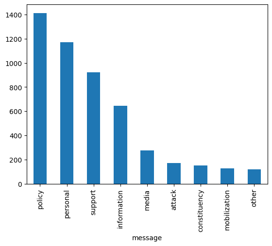

```python
kgposts.message.value_counts().plot.bar()
```

So now we know which type of message is the most popular, but what about the platform they're posted on? Let's use the same process to determine which platform appears to be the most popular.

```python
platform_type_count = kgposts.source.value_counts()
platform_type_count
```

| source | count |
| --- | --- |
| twitter | 2500 |
| facebook | 2500 |

**dtype:** int64

In this case, it looks like it is split perfectly in half! (the dataset contains 5,000 total posts). This was likely done purposefully during data collection. However, this raises a new question; although policy messages are the most popular overall, does this change across platforms? Let's find out!

```python
kgposts.groupby('source').message.value_counts()
```

| source | message | count |
| --- | --- | --- |
| facebook | policy | 744 |
|  | personal | 629 |
|  | support | 445 |
|  | information | 318 |
|  | media | 108 |
|  | other | 81 |
|  | attack | 63 |
|  | constituency | 57 |
|  | mobilization | 55 |
| twitter | policy | 667 |
|  | personal | 541 |
|  | support | 476 |
|  | information | 329 |
|  | media | 169 |
|  | attack | 109 |
|  | constituency | 95 |
|  | mobilization | 74 |
|  | other | 40 |

**dtype:** int64

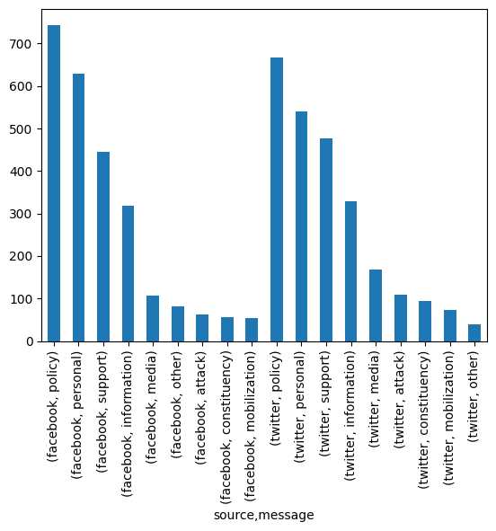

```python
#Make bar chart for both twitter and facebook message type.
platform_message_type = kgposts.groupby('source').message.value_counts()
platform_message_type.plot.bar()
```

It looks like the top five categories remain the same, but there are more than double the number of "other" posts on Facebook than on Twitter. Who knew!

Are legislators from certain states more likely to post attack messages than others?

```python
attack_by_state = kgposts.groupby('state')['message'].value_counts().loc[:, 'attack']
print(attack_by_state)
```

```
state
Alabama            1
Arizona            6
California        19
Colorado           2
Delaware           1
Florida            9
Georgia            5
Illinois           8
Indiana            7
Iowa               2
Kansas             5
Kentucky           7
Louisiana         14
Maryland           4
Massachusetts      1
Michigan           3
Missouri           3
Nevada             1
New Hampshire      1
New Jersey         3
New Mexico         1
New York           7
North Carolina     6
Ohio               5
Oklahoma           1
Pennsylvania       9
Rhode Island       1
South Carolina     3
South Dakota       1
Tennessee          4
Texas             23
Utah               2
Vermont            1
Virginia           1
Washington         1
West Virginia      2
Wisconsin          2
Name: count, dtype: int64
```

Whats the average number of attack messages per state?

```python
attack_by_state.mean()
```

```
np.float64(4.648648648648648)
```

Now lets compare against the top 5

```python
attack_by_state.nlargest(5)
```

| state | count |
| --- | --- |
| Texas | 23 |
| California | 19 |
| Louisiana | 14 |
| Florida | 9 |
| Pennsylvania | 9 |

**dtype:** int64

Texas, California and Louisiana send more than double the mean! They skew the distribution right. Lets see what the median is...

```python
attack_by_state.median()
```

```
3.0
```

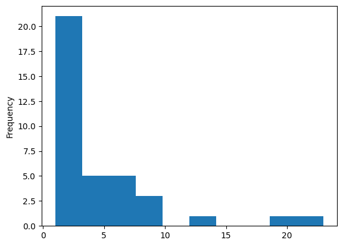

```python
attack_by_state.plot.hist()
```

Fill in the remaining NaN by party using webscraping

# Testing our Hypotheses

Party analysis: There were 3 independents in the Senate in 2015, Joe Manchin, Angus King, Bernie Sanders. All have or still do caucus with dems but should still be excluded from trends in party behavior

Given the large shifts in presidential election from 2012 to 2016, 4 metrics are neccessary for a robust understanding of the senators' home partisan makeup

## Tests and Tables

Lets start by mapping the average party margin (x) against the proportion of biased posts for each senator.

```python
grouped = senators2015_posts.groupby('legislator_Name')
bias_frequency = grouped['bias'].apply(lambda x: (x == 'partisan').sum() / len(x))
bias_senators_df = pd.DataFrame({'legislator_Name': bias_frequency.index, 'BiasFrequency': bias_frequency.values})
```

```python
bias_senators_df.head()
```

|  | legislator_Name | BiasFrequency |
| --- | --- | --- |
| 0 | Al Franken | 0.333333 |
| 1 | Amy Klobuchar | 0.500000 |
| 2 | Angus King | 0.500000 |
| 3 | Barbara Boxer | 0.166667 |
| 4 | Barbara Mikulski | 0.500000 |

```python
bias_senators_df = bias_senators_df.merge(senators2015_posts[['legislator_Name','party', 'state','avg','misaligned']], on='legislator_Name', how='left')
bias_senators_df = bias_senators_df.drop_duplicates()
bias_senators_df = bias_senators_df.rename(columns = {'state': 'State'})
bias_senators_df.head()
```

|  | legislator_Name | BiasFrequency | party | State | avg | misaligned |
| --- | --- | --- | --- | --- | --- | --- |
| 0 | Al Franken | 0.333333 | Democratic | Minnesota | -0.0435 | 0 |
| 9 | Amy Klobuchar | 0.500000 | Democratic | Minnesota | -0.0435 | 0 |
| 15 | Angus King | 0.500000 | Democratic | Maine | -0.0915 | 0 |
| 17 | Barbara Boxer | 0.166667 | Democratic | California | -0.2655 | 0 |
| 23 | Barbara Mikulski | 0.500000 | Democratic | Maryland | -0.2605 | 0 |

## Testing Bias Frequency and Party Leaning

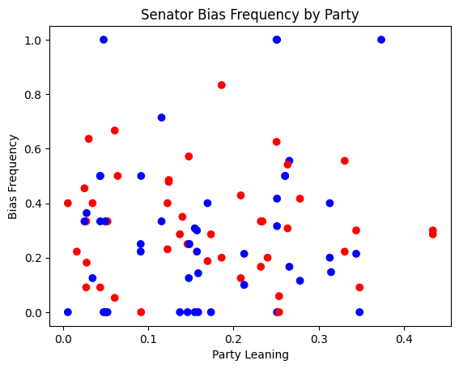

```python
import matplotlib.pyplot as plt
import math

x = abs(bias_senators_df['avg'])

# If you have another column to plot on the y-axis, replace 'index' with the column name
y = bias_senators_df.BiasFrequency

# Create a color list based on the 'party' column
colors = ['red' if party == 'Republican' else 'blue' for party in bias_senators_df['party']]

# Create the scatter plot
plt.scatter(x, y, c=colors)

# Set labels and title
plt.xlabel('Party Leaning')
plt.ylabel('Bias Frequency')  # Replace with the actual column name if used
plt.title('Senator Bias Frequency by Party')
```

```python
#first check for normality using a shapiro-wilk test
# Separate bias frequencies by party
dem_bias = bias_senators_df.loc[bias_senators_df['party'] == 'Democratic', 'BiasFrequency'].dropna()
rep_bias = bias_senators_df.loc[bias_senators_df['party'] == 'Republican', 'BiasFrequency'].dropna()
```

```python
from scipy.stats import shapiro

# Shapiro-Wilk Test for Democrats
stat_dem, p_dem = shapiro(dem_bias)
print(f"Democrats: statistic={stat_dem:.3f}, p-value={p_dem:.3f}")

# Shapiro-Wilk Test for Republicans
stat_rep, p_rep = shapiro(rep_bias)
print(f"Republicans: statistic={stat_rep:.3f}, p-value={p_rep:.3f}")
```

```
Democrats: statistic=0.858, p-value=0.000
Republicans: statistic=0.977, p-value=0.506
```

Democrat results reveal distribution is not normal, use Mann-Whitney U test.

```python
#calculate Mann-Whitney U test results
from scipy.stats import mannwhitneyu

stat, p = mannwhitneyu(dem_bias, rep_bias, alternative='two-sided')

print(f'Mann-Whitney U Test statistic = {stat:.3f}, p-value = {p:.3f}')
```

```
Mann-Whitney U Test statistic = 872.000, p-value = 0.196
```

Reveals no statistically significant difference between parties.

```python
from scipy.stats import spearmanr

bias_senators_df['avg']=abs(bias_senators_df['avg'])
bias_senators_df.dropna(inplace=True)
subset = bias_senators_df[['avg', 'BiasFrequency']]
corr, p_value = spearmanr(subset['avg'], subset['BiasFrequency'])
print(f"Spearman correlation: rho = {corr:.3f}, p-value = {p_value:.3f}")
```

```
Spearman correlation: rho = -0.004, p-value = 0.966
```

```python
#Spearman correlation results for each party
republican_df = bias_senators_df[bias_senators_df['party'] == 'Republican']
republican_corr = republican_df[['BiasFrequency', 'avg']].corr(method='spearman').iloc[0, 1]

# Calculate Spearman correlation for Democrats
democrat_df = bias_senators_df[bias_senators_df['party'] == 'Democratic']
democrat_corr = democrat_df[['BiasFrequency', 'avg']].corr(method='spearman').iloc[0, 1]

print("Spearman correlation for Republicans:", republican_corr)
print("Spearman correlation for Democrats:", democrat_corr)
```

```
Spearman correlation for Republicans: -0.06287267577731297
Spearman correlation for Democrats: 0.02818218588308732
```

## Testing Income and Bias Frequency

We append income to each senator according to state.

```python
Census_Data_Statewide.rename(columns={'state': 'State'}, inplace=True)
Census_Data_Statewide.head()
```

| State | TotalPop | Hispanic | White | Black | Native | Asian | Pacific | Men | Women | PublicWork | PrivateWork | IncomePerCap | Income |
| --- | --- | --- | --- | --- | --- | --- | --- | --- | --- | --- | --- | --- | --- |
| Alabama | 4830620.0 | 3.999312 | 66.341142 | 26.302823 | 0.456166 | 1.228718 | 0.022674 | 2341093.0 | 2489527.0 | 16.313379 | 78.223720 | 24091.518226 | 44531.621127 |
| Alaska | 733375.0 | 6.527632 | 62.376392 | 3.221664 | 13.416348 | 5.772953 | 1.179333 | 384160.0 | 349215.0 | 25.585478 | 67.935430 | 33413.428663 | 72351.565897 |
| Arizona | 6641928.0 | 30.338523 | 56.488653 | 3.959995 | 4.002505 | 2.917963 | 0.174526 | 3299088.0 | 3342840.0 | 15.162412 | 78.766693 | 25847.425295 | 50406.923807 |
| Arkansas | 2958208.0 | 6.870799 | 73.596324 | 15.436414 | 0.560054 | 1.352033 | 0.224281 | 1451913.0 | 1506295.0 | 16.455038 | 76.992934 | 22798.448086 | 41977.085065 |
| California | 38421464.0 | 38.380974 | 38.725035 | 5.616552 | 0.376623 | 13.515132 | 0.346866 | 19087135.0 | 19334329.0 | 14.042380 | 77.524942 | 30318.055748 | 63198.081918 |

```python
# Reset the index of Census_Data_Statewide to make 'State' a column
Census_Data_Statewide = Census_Data_Statewide.reset_index()

# Now you can merge using 'State' as the column
bias_senators_df = bias_senators_df.merge(Census_Data_Statewide[['State', 'Income']], on='State', how='left')
bias_senators_df.head()
```

|  | legislator_Name | BiasFrequency | party | State | avg | misaligned | Income |
| --- | --- | --- | --- | --- | --- | --- | --- |
| 0 | Al Franken | 0.333333 | Democratic | Minnesota | 0.0435 | 0 | 62873.880627 |
| 1 | Amy Klobuchar | 0.500000 | Democratic | Minnesota | 0.0435 | 0 | 62873.880627 |
| 2 | Angus King | 0.500000 | Democratic | Maine | 0.0915 | 0 | 49942.518486 |
| 3 | Barbara Boxer | 0.166667 | Democratic | California | 0.2655 | 0 | 63198.081918 |
| 4 | Barbara Mikulski | 0.500000 | Democratic | Maryland | 0.2605 | 0 | 77294.514031 |

[figure not shown]

```python
#Make a scatterplot comparing bias frequency and income


x = abs(bias_senators_df['avg'])

y = bias_senators_df['Income']

colors = ['red' if party == 'Republican' else 'blue' for party in bias_senators_df['party']]

plt.scatter(x, y, c=colors)

plt.xlabel('Income')
plt.ylabel('Bias Frequency')
plt.title('Bias Frequency vs Income')
plt.show()
```

### Check for Normality

Bias frequency is not a normal distribution. Use Spearman.

### Spearman Correlation

```python
from scipy.stats import spearmanr

subset3 = bias_senators_df[['Income', 'BiasFrequency']]
corr, p_value = spearmanr(subset3['Income'], subset3['BiasFrequency'])
print(f"Spearman correlation: rho = {corr:.3f}, p-value = {p_value:.3f}")
```

```
Spearman correlation: rho = 0.058, p-value = 0.582
```

## Diversity and Bias

Next, we can use a Shannon diversity index to create a unified metric on diversity.

```python
race_columns = ['White', 'Black', 'Asian', 'Hispanic', 'Native', 'Pacific']
Census_Data_Statewide[race_columns] = Census_Data_Statewide[race_columns] / 100
```

```python
import numpy as np

def shannon_entropy(row):
    proportions = row[race_columns]
    proportions = proportions[proportions > 0]  # Avoid log(0)
    # Ensure proportions are of a numerical dtype compatible with NumPy's log
    proportions = proportions.astype(np.float64)
    return -(proportions * np.log(proportions)).sum()

Census_Data_Statewide['diversity_entropy'] = Census_Data_Statewide.apply(shannon_entropy, axis=1)
Census_Data_Statewide.head()
```

|  | State | TotalPop | Hispanic | White | Black | Native | Asian | Pacific | Men | Women | PublicWork | PrivateWork | IncomePerCap | Income | diversity_entropy |
| --- | --- | --- | --- | --- | --- | --- | --- | --- | --- | --- | --- | --- | --- | --- | --- |
| 0 | Alabama | 4830620.0 | 0.039993 | 0.663411 | 0.263028 | 0.004562 | 0.012287 | 0.000227 | 2341093.0 | 2489527.0 | 16.313379 | 78.223720 | 24091.518226 | 44531.621127 | 0.832794 |
| 1 | Alaska | 733375.0 | 0.065276 | 0.623764 | 0.032217 | 0.134163 | 0.057730 | 0.011793 | 384160.0 | 349215.0 | 25.585478 | 67.935430 | 33413.428663 | 72351.565897 | 1.069729 |
| 2 | Arizona | 6641928.0 | 0.303385 | 0.564887 | 0.039600 | 0.040025 | 0.029180 | 0.001745 | 3299088.0 | 3342840.0 | 15.162412 | 78.766693 | 25847.425295 | 50406.923807 | 1.055376 |
| 3 | Arkansas | 2958208.0 | 0.068708 | 0.735963 | 0.154364 | 0.005601 | 0.013520 | 0.002243 | 1451913.0 | 1506295.0 | 16.455038 | 76.992934 | 22798.448086 | 41977.085065 | 0.798946 |
| 4 | California | 38421464.0 | 0.383810 | 0.387250 | 0.056166 | 0.003766 | 0.135151 | 0.003469 | 19087135.0 | 19334329.0 | 14.042380 | 77.524942 | 30318.055748 | 63198.081918 | 1.207798 |

```python
#add diversity_entropy to bias_senators_df
bias_senators_df = bias_senators_df.merge(Census_Data_Statewide[['State', 'diversity_entropy']], on='State', how='left')
bias_senators_df.head()
```

|  | legislator_Name | BiasFrequency | party | State | avg | misaligned | Income | diversity_entropy |
| --- | --- | --- | --- | --- | --- | --- | --- | --- |
| 0 | Al Franken | 0.333333 | Democratic | Minnesota | 0.0435 | 0 | 62873.880627 | 0.655924 |
| 1 | Amy Klobuchar | 0.500000 | Democratic | Minnesota | 0.0435 | 0 | 62873.880627 | 0.655924 |
| 2 | Angus King | 0.500000 | Democratic | Maine | 0.0915 | 0 | 49942.518486 | 0.249952 |
| 3 | Barbara Boxer | 0.166667 | Democratic | California | 0.2655 | 0 | 63198.081918 | 1.207798 |
| 4 | Barbara Mikulski | 0.500000 | Democratic | Maryland | 0.2605 | 0 | 77294.514031 | 1.094039 |

### Check for Normality

```python
# Test diversity
stat_div, p_div = shapiro(bias_senators_df['diversity_entropy'].dropna())
print(f'Diversity: statistic={stat_div:.3f}, p-value={p_div:.3f}')

# Test bias frequency
stat_bias, p_bias = shapiro(bias_senators_df['BiasFrequency'].dropna())
print(f'Bias Frequency: statistic={stat_bias:.3f}, p-value={p_bias:.3f}')
```

```
Diversity: statistic=0.966, p-value=0.016
Bias Frequency: statistic=0.917, p-value=0.000
```

Data is not normal, use Spearman Correlation.

### Spearman Correlation

```python
from scipy.stats import spearmanr

subset2 = bias_senators_df[['diversity_entropy', 'BiasFrequency']]
corr, p_value = spearmanr(subset2['diversity_entropy'], subset2['BiasFrequency'])
print(f"Spearman correlation: rho = {corr:.3f}, p-value = {p_value:.3f}")
```

```
Spearman correlation: rho = 0.086, p-value = 0.416
```

## Message Frequency and Party Leaning

```python
#normalize message_frequency and avg
from sklearn.preprocessing import StandardScaler

scaler = StandardScaler()
bias_senators_df[['Income', 'avg']] = scaler.fit_transform(bias_senators_df[['Income', 'avg']])
```

```python
# Creates a df that has the frequency of each message, organized by senator, keeping party, average and misaligned
# Group by senator and message type, then count occurrences
message_frequency = senators2015_posts.groupby(['legislator_Name', 'message'])['message'].count().reset_index(name='frequency')

# Pivot the table to have message types as columns
message_frequency = message_frequency.pivot(index='legislator_Name', columns='message', values='frequency').fillna(0)
senators2015_posts.rename(columns={'state': 'State'}, inplace=True)
# Merge with senator information
senator_info = senators2015_posts[['legislator_Name', 'party', 'avg', 'misaligned', 'State']].drop_duplicates()  # Get unique senator info
message_frequency = message_frequency.merge(senator_info, on='legislator_Name', how='left')

# Reset index to make 'legislator_Name' a regular column
message_frequency = message_frequency.reset_index()

message_frequency['avg']= abs(message_frequency['avg'])
# merge Income, State and diversity_entropy from bias_senators_df
message_frequency = message_frequency.merge(bias_senators_df[['State', 'Income', 'diversity_entropy']], on='State', how='left')
# Display the resulting DataFrame
message_frequency.drop_duplicates(subset=['legislator_Name'])
message_frequency.head()
```

|  | index | legislator_Name | attack | constituency | information | media | mobilization | other | personal | policy | support | party | avg | misaligned | State | Income | diversity_entropy |
| --- | --- | --- | --- | --- | --- | --- | --- | --- | --- | --- | --- | --- | --- | --- | --- | --- | --- |
| 0 | 0 | Al Franken | 0.0 | 0.0 | 0.0 | 0.0 | 3.0 | 0.0 | 1.0 | 2.0 | 3.0 | Democratic | 0.0435 | 0 | Minnesota | 0.827464 | 0.655924 |
| 1 | 0 | Al Franken | 0.0 | 0.0 | 0.0 | 0.0 | 3.0 | 0.0 | 1.0 | 2.0 | 3.0 | Democratic | 0.0435 | 0 | Minnesota | 0.827464 | 0.655924 |
| 2 | 1 | Amy Klobuchar | 0.0 | 0.0 | 0.0 | 0.0 | 0.0 | 0.0 | 1.0 | 4.0 | 1.0 | Democratic | 0.0435 | 0 | Minnesota | 0.827464 | 0.655924 |
| 3 | 1 | Amy Klobuchar | 0.0 | 0.0 | 0.0 | 0.0 | 0.0 | 0.0 | 1.0 | 4.0 | 1.0 | Democratic | 0.0435 | 0 | Minnesota | 0.827464 | 0.655924 |
| 4 | 2 | Angus King | 0.0 | 0.0 | 0.0 | 1.0 | 0.0 | 0.0 | 0.0 | 0.0 | 1.0 | Democratic | 0.0915 | 0 | Maine | -0.568629 | 0.249952 |

Normalize Income and avg margin

```python
from sklearn.preprocessing import StandardScaler

scaler = StandardScaler()
message_frequency[['Income', 'avg']] = scaler.fit_transform(message_frequency[['Income', 'avg']])
```

```python
import pandas as pd
from scipy.stats import linregress
from sklearn.preprocessing import StandardScaler

# Define message types
message_types = ['attack', 'constituency', 'information', 'media',
                 'mobilization', 'other', 'personal', 'policy', 'support']

# Calculate total number of messages per row
message_frequency['total_messages'] = message_frequency[message_types].sum(axis=1)

# Normalize message types to proportions
for msg in message_types:
    message_frequency[f'{msg}_prop'] = message_frequency[msg] / message_frequency['total_messages']

# Scale Income and avg
scaler = StandardScaler()
message_frequency[['Income', 'avg']] = scaler.fit_transform(message_frequency[['Income', 'avg']])

# Now, regress using proportions
results = []

for msg in message_types:
    x = message_frequency['avg']
    y = message_frequency[f'{msg}_prop']  # use the normalized proportions

    # Drop any rows with missing values (if any)
    mask = (~x.isna()) & (~y.isna())
    x = x[mask]
    y = y[mask]

    slope, intercept, r_value, p_value, std_err = linregress(x, y)

    results.append({
        'Message Type': msg,
        'Slope': slope,
        'Intercept': intercept,
        'p-value': p_value,
        'R-squared': r_value**2
    })

# Put results in a DataFrame
results_df = pd.DataFrame(results)

# View
print(results_df)
```

```
   Message Type     Slope  Intercept   p-value  R-squared
0        attack -0.000242   0.018284  0.948170   0.000023
1  constituency  0.008156   0.017540  0.019532   0.029598
2   information -0.015502   0.121381  0.166746   0.010479
3         media  0.011876   0.068373  0.128153   0.012672
4  mobilization  0.001921   0.038312  0.740266   0.000605
5         other -0.000197   0.015819  0.956673   0.000016
6      personal -0.036410   0.212505  0.016206   0.031346
7        policy  0.033591   0.305495  0.060582   0.019214
8       support -0.003193   0.202291  0.761460   0.000508
```

## Message Frequency and Income

```python
import pandas as pd
from scipy.stats import linregress

# Assume you already have 'Income' and 'total_messages' calculated and message proportions made
message_types = ['attack', 'constituency', 'information', 'media',
                 'mobilization', 'other', 'personal', 'policy', 'support']

# Store results
income_results = []

for msg in message_types:
    x = message_frequency['Income']  # <-- now Income instead of avg
    y = message_frequency[f'{msg}_prop']  # normalized proportions

    # Drop missing values
    mask = (~x.isna()) & (~y.isna())
    x = x[mask]
    y = y[mask]

    slope, intercept, r_value, p_value, std_err = linregress(x, y)

    income_results.append({
        'Message Type': msg,
        'Slope': slope,
        'Intercept': intercept,
        'p-value': p_value,
        'R-squared': r_value**2
    })

# Create results DataFrame
income_results_df = pd.DataFrame(income_results)

# View
print(income_results_df)
```

```
   Message Type     Slope  Intercept   p-value  R-squared
0        attack -0.001323   0.018284  0.721777   0.000698
1  constituency  0.000869   0.017540  0.804898   0.000336
2   information -0.023220   0.121381  0.037697   0.023513
3         media -0.007931   0.068373  0.310421   0.005653
4  mobilization -0.015146   0.038312  0.008338   0.037618
5         other -0.002077   0.015819  0.567445   0.001800
6      personal  0.011101   0.212505  0.466778   0.002914
7        policy  0.025043   0.305495  0.162722   0.010679
8       support  0.012685   0.202291  0.226880   0.008013
```

## Message Frequency and Diversity

```python
import pandas as pd
from scipy.stats import linregress

# Your list of message types (already normalized)
message_types = ['attack', 'constituency', 'information', 'media',
                 'mobilization', 'other', 'personal', 'policy', 'support']

# Store results
diversity_results = []

for msg in message_types:
    x = message_frequency['diversity_entropy']  # <-- Now using diversity entropy
    y = message_frequency[f'{msg}_prop']

    # Drop missing values
    mask = (~x.isna()) & (~y.isna())
    x = x[mask]
    y = y[mask]

    slope, intercept, r_value, p_value, std_err = linregress(x, y)

    diversity_results.append({
        'Message Type': msg,
        'Slope': slope,
        'Intercept': intercept,
        'p-value': p_value,
        'R-squared': r_value**2
    })

# Create results DataFrame
diversity_results_df = pd.DataFrame(diversity_results)

# View
print(diversity_results_df)
```

```
   Message Type     Slope  Intercept   p-value  R-squared
0        attack  0.023107   0.000383  0.105941   0.014298
1  constituency -0.020128   0.033134  0.137142   0.012101
2   information -0.083605   0.186150  0.052750   0.020459
3         media -0.044577   0.102907  0.139055   0.011985
4  mobilization -0.070180   0.092680  0.001471   0.054205
5         other  0.007700   0.009853  0.582800   0.001661
6      personal  0.135611   0.107447  0.020415   0.029185
7        policy  0.121299   0.211525  0.079346   0.016817
8       support -0.069226   0.255920  0.086904   0.016018
```

# Results

## Party margin and Bias

Spearman Correlation Coefficient:

- Spearman correlation: rho = -0.004, p-value = 0.966
- relationship is weak and not statistically significant

Mann Whitney U Test

- differences among parties in party margin and bias are not statistically significant

## Income and Bias

- Spearman correlation: rho = 0.058, p-value = 0.582
- there is not a statistically significant relationship

## Diversity and Bias

- Spearman correlation: rho = 0.086, p-value = 0.416
- there is not a statistically significant relationship

## Message Frequency and Party Leaning

Statistically significant:

- constituency, slight positive
- personal, stronger negative

Suprisingly, the following types are not significantly correlated to margin: policy, attack, support, media, mobilization

## Message Frequency and Income

statistically significant:

- information, slight negative
- mobilization, slight negative

## Message Frequency and Diversity

statistically significant:

# Findings and implications

## Interpretation and Implications

Although differences in how message content is categorized limit direct comparison with Grimmer’s work, several implications still emerge from our findings.

### Information and Policy Messaging Is Uniform Across Districts

- Both **information** and **policy** tweets were shared at similar rates across **aligned** and **marginal** districts.
- Importantly, messages expressing **support** for specific policies were categorized separately from neutral **policy** content.

This suggests a baseline use of Twitter for **informational parity**, likely stemming from early norms of digital political communication—where tweets were primarily used to **share updates and avoid controversy**.

### Platform Format May Influence Tone

Twitter’s structure—**informal, high-frequency, and low-cost**—could contribute to:

- Aligned legislators feeling **less pressure** to use Twitter strictly for ideological promotion.
- Universal use of the platform for **appropriations and policy updates**, mimicking press releases.

### Unexpected Trend: More Constituency Messages in Aligned Districts

- We found a **higher frequency of constituency-oriented messages** from aligned legislators.
- This contradicts Grimmer’s model, where marginal legislators are expected to emphasize constituent services to avoid ideological conflict.

> A possible explanation: aligned legislators may feel comfortable **generalizing** about shared district values, whereas marginal legislators avoid doing so due to ideological diversity.

## Personal Branding as a New Marginal Strategy

The **increased use of personal messages** by marginal legislators suggests a strategic shift:

- Rather than taking overt policy stances, they promote **personal values, relatability, and lifestyle content**.
- Examples include posts featuring family, religious activities, or community events—messages that would be **unusual in formal press releases** but are natural on social media.

This behavior reflects an **adaptive form of homestyle** that allows marginal senators to **signal bipartisan appeal** without polarizing policy declarations.

## Temporal & Cultural Limitation

Our research analyzes congressional behavior in **2015**, whereas Grimmer’s conclusions are based on **2006–2008** data. The gap includes:

- A significant rise in social media usage.
- Shifts in voter ideology and partisan dynamics.

As a result, we cannot conclusively attribute the observed changes to Twitter alone. **Congress itself may have evolved.**

## New Voter Alignments as a Mechanism

A possible explanation for changes in strategy is the **decline of true moderates** and rise of **independents with strong, non-aligned views**.

- Rather than seeing parties as equally favorable, these voters hold **intense but ideologically mixed** opinions (Broockman & Kalla, 2023).
- Marginal representatives may respond by **taking strong positions across party lines**—a strategy suited for appealing to independents.

## Future Research Needed

To fully isolate whether these patterns stem from **Twitter's affordances** or **structural shifts in Congress**, we recommend:

- A comparative analysis of **press releases and tweets post-2020**.
- Inclusion of **constituency demographics** (e.g. income, diversity) as control variables.

## Final Reflection

Regardless of the source, one reality holds:

> **On Twitter, every senator appears to be a position-taker.**

This challenges Grimmer’s original conclusion and raises a pressing question:  
**Is Congress truly more polarized now—or are digital platforms amplifying partisan cues beyond reality?**

## Reconsidering Grimmer: Income and Diversity as Potential Confounders

Our research revealed statistically significant correlations between **constituency income and diversity** and the **frequency of specific message types** shared on Twitter. These findings suggest that socioeconomic and demographic factors—**not accounted for in Grimmer’s 2006–2008 press release study**—could confound or qualify his conclusions.

### Our Supporting Findings

These correlations suggest that **lower-income and more diverse constituencies** receive more frequent **informational and personalized content**, potentially reflecting efforts by senators to build trust or expand cross-cutting appeal, especially in heterogeneous districts.

## 2008–2015 Demographic Shifts and Political Margins

Significant demographic shifts occurred between **2008 and 2015** that likely **altered the partisan landscape** and the representational incentives Grimmer modeled:

- **Increasing racial and ethnic diversity**: According to Pew (2015), the U.S. saw a 2.5% increase in non-white voters between 2008 and 2015, with Latinos and Asian Americans driving much of this growth. These groups tend to live in urban, often Democratic-leaning districts, **reducing ideological homogeneity** even in "aligned" areas.
- **Urbanization and education growth**: More voters moved to urban centers, and college completion rose. Urban areas tend to be ideologically left-leaning but can be **internally diverse** in priorities and identity politics, weakening the concept of a uniformly aligned district.
- **Widening income inequality**: Economic stress during and after the Great Recession increased **class-based distinctions** in political messaging. Senators may have shifted strategies to address economic grievances and mobilize disaffected voters online.

These shifts indicate that **district alignment** (as used in Grimmer’s model) may now **mask important variations** within districts—particularly among **marginal or transitioning areas**. What once seemed like a partisan alignment might actually involve **intraparty diversity** or emerging independent ideologies.

## Implication: Expanded Model for Digital Homestyle

Given Twitter’s informality and frequency, it allows for **new forms of homestyle representation**:

- **Personal branding** (as seen in higher personal tweets in diverse districts)
- **Equity-based communication strategies**
- **Digital outreach to underrepresented or politically disengaged groups**

This evidence suggests that **income and diversity should be modeled as independent variables** in future studies evaluating message tone, content, and frequency—especially on digital platforms.

> Grimmer’s model provides a strong foundation, but our work suggests it should be revisited with a **multi-dimensional view of constituency characteristics** that includes race, income, and education alongside partisan composition.

# See more

To better understand how social media reshapes political homestyle, it's critical to examine not only content but the characteristics of constituencies that influence how representatives engage with them digitally.

## Foundational Resources (Basic Concepts)

1. **Richard Fenno**  
   *Home Style: House Members in Their Districts*. Little, Brown, 1978.  
   *A classic on how representatives connect with constituents—core to understanding digital homestyle.*
2. **Golbeck, Jennifer, Grimes, Justin M., & Rogers, Anthony**  
   *Twitter Use by the U.S. Congress*.  
   [PDF](https://www.academia.edu/9165717/Twitter_use_by_the_U_S_Congress)  
   *Explores early, largely impersonal use of Twitter by members of Congress.*
3. **Grimmer, Justin**  
   *Appropriators Not Position Takers: The Distorting Effects of Electoral Incentives on Congressional Representation*. University of Chicago Press, 2013.  
   *Defines how electoral incentives shape communication strategies.*

## Deep-Dive Studies (Advanced/Empirical)

4. **Kreiss, Daniel & McGregor, Shannon C.**  
   *Technology Firms Shape Political Communication: The Work of Microsoft, Facebook, Twitter, and Google...*  
   PDF  
   *Illustrates how tech platforms influence political messaging.*
5. **Barberá, Pablo**  
   *Birds of the Same Feather Tweet Together: Bayesian Ideal Point Estimation Using Twitter Data*  
   [DOI](https://onlinelibrary.wiley.com/doi/full/10.1111/ajps.12000)  
   *Estimates political ideology using Twitter data.*
6. **Shogan, Colleen J.**  
   *The Contemporary Presidency: Congressional Communication in the Digital Age*  
   [Wiley Link](https://onlinelibrary.wiley.com/doi/abs/10.1111/j.1741-5705.2010.03753.x)  
   *Shows the transformation of political communication in the digital era.*

## 🔗 Related Work (Contextual Trends)

7. **Unite America Institute**  
   *Growing Cohort of Independent Voters Becomes Critical Segment of Electorate*  
   [Read Here](https://www.uniteamerica.org/articles/research-brief-growing-cohort-of-independent-voters-becomes-critical-segment-of-electorate)
8. **Broockman, David & Kalla, Joshua**  
   *Candidate Ideology and Vote Choice in the 2020 US Presidential Election*  
   [DOI](https://journals.sagepub.com/doi/abs/10.1177/1532673X231220652)
9. **Pew Research Center**  
   *News Platform Fact Sheet*  
   [View Report](https://www.pewresearch.org/journalism/fact-sheet/news-platform-fact-sheet/)

# Sources

- Barberá, Pablo. “Birds of the Same Feather Tweet Together: Bayesian Ideal Point Estimation Using Twitter Data.” American Journal of Political Science, vol. 59, no. 4, 2015, pp. 987–1002. Wiley Online Library, https://onlinelibrary.wiley.com/doi/full/10.1111/ajps.12000 (https://onlinelibrary.wiley.com/doi/full/10.1111/ajps.12000).
- Golbeck, Jennifer, Justin M. Grimes, and Anthony Rogers. “Twitter Use by the U.S. Congress.” Academia.edu, https://www.academia.edu/9165717/Twitter_use_by_the_U_S_Congress (https://www.academia.edu/9165717/Twitter_use_by_the_U_S_Congress). Accessed 7 May 2025.
- Grimmer, Justin. Appropriators Not Position Takers: The Distorting Effects of Electoral Incentives on Congressional Representation. University of Chicago Press, 2013.
- Kreiss, Daniel, and Shannon C. McGregor. “Technology Firms Shape Political Communication: The Work of Microsoft, Facebook, Twitter, and Google with Campaigns during the 2016 U.S. Presidential Cycle.” DanielKreiss.com, 2018, https://danielkreiss.com/wp-content/uploads/2018/01/kreissmcgregortechnology-firms-shape-political-communication-the-work-of-microsoft-facebook-twitter-and-google-with-campaigns-during-the-2016-u-s-presidential-cycle.pdf (https://danielkreiss.com/wp-content/uploads/2018/01/kreissmcgregortechnology-firms-shape-political-communication-the-work-of-microsoft-facebook-twitter-and-google-with-campaigns-during-the-2016-u-s-presidential-cycle.pdf).
- Shearer, Elisa. “News Platform Fact Sheet.” Pew Research Center’s Journalism Project, Pew Research Center, 27 Sept. 2023, https://www.pewresearch.org/journalism/fact-sheet/news-platform-fact-sheet/ (https://www.pewresearch.org/journalism/fact-sheet/news-platform-fact-sheet/) .
- Unite America Institute. “Research Brief: Growing Cohort of Independent Voters Becomes Critical Segment of Electorate.” Unite America , 5 Apr. 2023, https://www.uniteamerica.org/articles/research-brief-growing-cohort-of-independent-voters-becomes-critical-segment-of-electorate (https://www.uniteamerica.org/articles/research-brief-growing-cohort-of-independent-voters-becomes-critical-segment-of-electorate) .